# Notebook

### **Potential Customer Prediction**

**Problem statement**: we are looking to build an ML model that would predict which leads are more likely to be convereted to paid customers, so that ExtraaLearn can dedicate more time to nurture them and gain more revenue.

```python
# Importing the necessary libraries

import warnings
from statsmodels.tools.sm_exceptions import ConvergenceWarning
import pandas as pd
import numpy as np
from sklearn.model_selection import train_test_split
import matplotlib.pyplot as plt
import seaborn as sns
import statsmodels.stats.api as sms
from statsmodels.stats.outliers_influence import variance_inflation_factor
import statsmodels.api as sm
from statsmodels.tools.tools import add_constant
from sklearn.linear_model import LogisticRegression
from sklearn.tree import DecisionTreeClassifier
from sklearn import tree
from sklearn.ensemble import RandomForestClassifier
from sklearn.model_selection import GridSearchCV
from sklearn import metrics
from sklearn.metrics import (
    f1_score,
    accuracy_score,
    recall_score,
    precision_score,
    confusion_matrix,
    roc_auc_score,
    classification_report,
    precision_recall_curve,
    roc_curve,
    make_scorer,
)
```

```python
# Loading the dataset
learn = pd.read_csv("/content/drive/MyDrive/ExtraaLearn.csv")
data = learn.copy()
```

### **Data Overview**

```python
# Observe the top five rows of the dataset
data.head()
```

|  | ID | age | current_occupation | first_interaction | profile_completed | website_visits | time_spent_on_website | page_views_per_visit | last_activity | print_media_type1 | print_media_type2 | digital_media | educational_channels | referral | status |
| --- | --- | --- | --- | --- | --- | --- | --- | --- | --- | --- | --- | --- | --- | --- | --- |
| 0 | EXT001 | 57 | Unemployed | Website | High | 7 | 1639 | 1.861 | Website Activity | Yes | No | Yes | No | No | 1 |
| 1 | EXT002 | 56 | Professional | Mobile App | Medium | 2 | 83 | 0.320 | Website Activity | No | No | No | Yes | No | 0 |
| 2 | EXT003 | 52 | Professional | Website | Medium | 3 | 330 | 0.074 | Website Activity | No | No | Yes | No | No | 0 |
| 3 | EXT004 | 53 | Unemployed | Website | High | 4 | 464 | 2.057 | Website Activity | No | No | No | No | No | 1 |
| 4 | EXT005 | 23 | Student | Website | High | 4 | 600 | 16.914 | Email Activity | No | No | No | No | No | 0 |

```python
# statistical summary of the columns in the dataset
data.describe().T
```

|  | count | mean | std | min | 25% | 50% | 75% | max |
| --- | --- | --- | --- | --- | --- | --- | --- | --- |
| age | 4612.0 | 46.201214 | 13.161454 | 18.0 | 36.00000 | 51.000 | 57.00000 | 63.000 |
| website_visits | 4612.0 | 3.566782 | 2.829134 | 0.0 | 2.00000 | 3.000 | 5.00000 | 30.000 |
| time_spent_on_website | 4612.0 | 724.011275 | 743.828683 | 0.0 | 148.75000 | 376.000 | 1336.75000 | 2537.000 |
| page_views_per_visit | 4612.0 | 3.026126 | 1.968125 | 0.0 | 2.07775 | 2.792 | 3.75625 | 18.434 |
| status | 4612.0 | 0.298569 | 0.457680 | 0.0 | 0.00000 | 0.000 | 1.00000 | 1.000 |

Observations:

- The average age is around 46 years old with a range from 18 to 63.
- The average visits of the website is about 3 times.
- The average time spent on website is 724 seconds or about 12 minutes.

```python
# Plotting histograms
data.hist(figsize=(14,14))
plt.show()
```

[output not shown]

Observations:

- When it comes to age, the histogram is clearly left skewed, with many leads above 55.
- Website visits is right skewed. Most people frequent the website less than 5 times.
- People also tend to view 2.5 pages per visit.

```python
# Looking for duplicated data
data.duplicated
```

```python
# Checking for missing values
data.isnull().sum()
```

[output not shown]

Observation:

- We have no missing values in our dataset.

```python
# Checking the data types per column
data.info()
```

```
<class 'pandas.core.frame.DataFrame'>
RangeIndex: 4612 entries, 0 to 4611
Data columns (total 15 columns):
 #   Column                 Non-Null Count  Dtype
---  ------                 --------------  -----
 0   ID                     4612 non-null   object
 1   age                    4612 non-null   int64
 2   current_occupation     4612 non-null   object
 3   first_interaction      4612 non-null   object
 4   profile_completed      4612 non-null   object
 5   website_visits         4612 non-null   int64
 6   time_spent_on_website  4612 non-null   int64
 7   page_views_per_visit   4612 non-null   float64
 8   last_activity          4612 non-null   object
 9   print_media_type1      4612 non-null   object
 10  print_media_type2      4612 non-null   object
 11  digital_media          4612 non-null   object
 12  educational_channels   4612 non-null   object
 13  referral               4612 non-null   object
 14  status                 4612 non-null   int64
dtypes: float64(1), int64(4), object(10)
memory usage: 540.6+ KB
```

Observation:

- The most popular data type in this data data set is object

```python
# this funciton is used for finding unique values in each column
data.nunique()
```

```
ID                       4612
age                        46
current_occupation          3
first_interaction           2
profile_completed           3
website_visits             27
time_spent_on_website    1623
page_views_per_visit     2414
last_activity               3
print_media_type1           2
print_media_type2           2
digital_media               2
educational_channels        2
referral                    2
status                      2
dtype: int64
```

Observation:

- ID column is an identifier which is unique for each lead so we will drop this column as it would not add any value to our analysis.

```python
# Dropping ID column
data.drop(['ID'], axis=1, inplace=True)
```

```python
# Creating a list of categorical variables
cat_col = list(data.select_dtypes("object").columns)

# printing number of count of each unique value in every column
for column in cat_col:
    print(data[column].value_counts())
    print("-" * 50)
```

```
Professional    2616
Unemployed      1441
Student          555
Name: current_occupation, dtype: int64
--------------------------------------------------
Website       2542
Mobile App    2070
Name: first_interaction, dtype: int64
--------------------------------------------------
High      2264
Medium    2241
Low        107
Name: profile_completed, dtype: int64
--------------------------------------------------
Email Activity      2278
Phone Activity      1234
Website Activity    1100
Name: last_activity, dtype: int64
--------------------------------------------------
No     4115
Yes     497
Name: print_media_type1, dtype: int64
--------------------------------------------------
No     4379
Yes     233
Name: print_media_type2, dtype: int64
--------------------------------------------------
No     4085
Yes     527
Name: digital_media, dtype: int64
--------------------------------------------------
No     3907
Yes     705
Name: educational_channels, dtype: int64
--------------------------------------------------
No     4519
Yes      93
Name: referral, dtype: int64
--------------------------------------------------
```

Observation:

# **Univariate Analysis**

```python
# Creating a function to plot a boxplot and a histogram along the same scale.
def histogram_boxplot(data, feature, figsize=(12, 7), kde=False, bins=None):
    f2, (ax_box2, ax_hist2) = plt.subplots(
        nrows=2,  # Number of rows of the subplot grid= 2
        sharex=True,  # x-axis will be shared among all subplots
        gridspec_kw={"height_ratios": (0.25, 0.75)},
        figsize=figsize,
    )  # creating the 2 subplots
    sns.boxplot(
        data=data, x=feature, ax=ax_box2, showmeans=True, color="yellow"
    )  # boxplot will be created and a star will indicate the mean value of the column
    sns.histplot(
        data=data, x=feature, kde=kde, ax=ax_hist2, bins=bins, palette="winter"
    ) if bins else sns.histplot(
        data=data, x=feature, kde=kde, ax=ax_hist2
    )  # For histogram
    ax_hist2.axvline(
        data[feature].mean(), color="red", linestyle="--"
    )  # Add mean to the histogram
    ax_hist2.axvline(
        data[feature].median(), color="black", linestyle="-"
    )
```

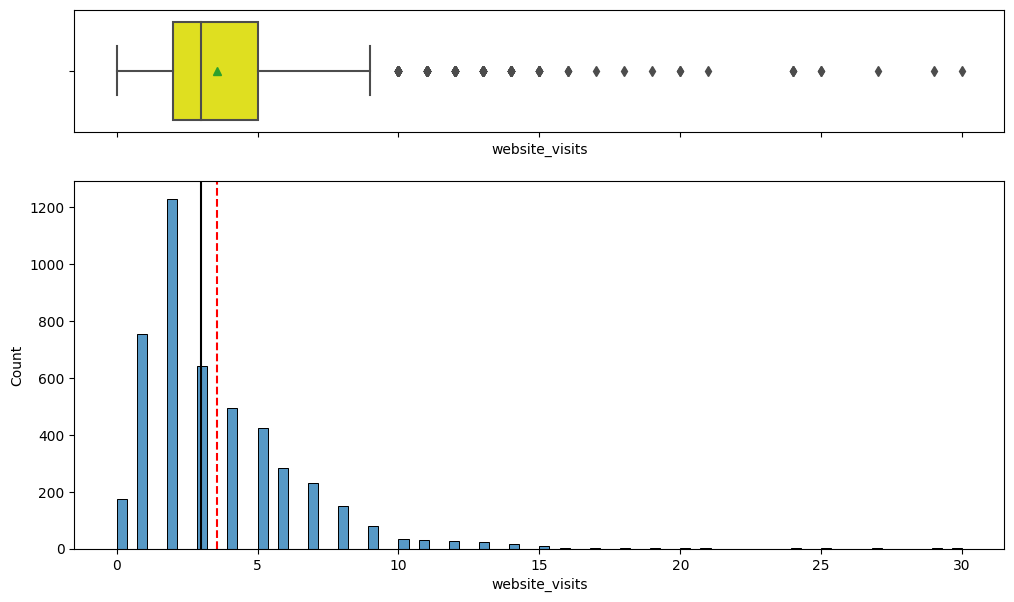

```python
histogram_boxplot(data, "website_visits")
```

Observation:

```python
# Leads that have not visited web-site
data[data["website_visits"]==0].shape
```

```
(174, 14)
```

```python
histogram_boxplot(data, "time_spent_on_website")
```

[output not shown]

Observation:

- The histogram is right skewed.
- The average time spent on the website is about 750 seconds or 12.5 minutes.

```python
histogram_boxplot(data, "page_views_per_visit")
```

[output not shown]

Observations:

- The box plot shows a lot of outliers
- According to the histogram we see average page view per visit is 3

```python
# Creating a heatmap
cols_list = data.select_dtypes(include=np.number).columns.tolist()

plt.figure(figsize=(12, 7))
sns.heatmap(
    data[cols_list].corr(), annot=True, vmin=-1, vmax=1, fmt=".2f", cmap="Spectral"
)
plt.show()
```

[output not shown]

Observation:

- According to the heatmap, we see there's a positive correlation between time spent on site and status
- There seems to be a negative correlation between age and page views per visit

```python
# function to plot distributions wrt target
def distribution_plot_wrt_target(data, predictor, target):

    fig, axs = plt.subplots(2, 2, figsize=(14, 12))

    target_uniq = data[target].unique()

    axs[0, 0].set_title("Distribution of target for target=" + str(target_uniq[0]))
    sns.histplot(
        data=data[data[target] == target_uniq[0]],
        x=predictor,
        kde=True,
        ax=axs[0, 0],
        color="orange",
        stat="density",
    )

    axs[0, 1].set_title("Distribution of target for target=" + str(target_uniq[1]))
    sns.histplot(
        data=data[data[target] == target_uniq[1]],
        x=predictor,
        kde=True,
        ax=axs[0, 1],
        color="red",
        stat="density",
    )

    axs[1, 0].set_title("Boxplot w.r.t target")
    sns.boxplot(data=data, x=target, y=predictor, ax=axs[1, 0], palette="gist_rainbow")

    axs[1, 1].set_title("Boxplot (without outliers) w.r.t target")
    sns.boxplot(
        data=data,
        x=target,
        y=predictor,
        ax=axs[1, 1],
        showfliers=False,
        palette="gist_rainbow",
    )

    plt.tight_layout()
    plt.show()
```

```python
def stacked_barplot(data, predictor, target):

    count = data[predictor].nunique()
    sorter = data[target].value_counts().index[-1]
    tab1 = pd.crosstab(data[predictor], data[target], margins=True).sort_values(
        by=sorter, ascending=False
    )
    print(tab1)
    print("-" * 120)
    tab = pd.crosstab(data[predictor], data[target], normalize="index").sort_values(
        by=sorter, ascending=False
    )
    tab.plot(kind="bar", stacked=True, figsize=(count + 5, 5))
    plt.legend(
        loc="lower left", frameon=False,
    )
    plt.legend(loc="upper left", bbox_to_anchor=(1, 1))
    plt.show()
```

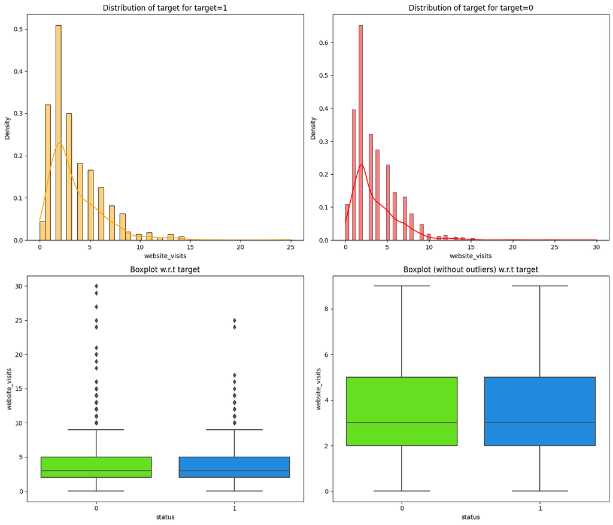

```python
distribution_plot_wrt_target(data, "website_visits","status")
```

Observation:

- On the boxplot without outliers for website visits vs status, we notice that both yes and no status are have identical boxes. However on the otherside with outliers, we notice that Status no have more outliers scattered.
- The histogram on both yes and no status is right skewed. Peaking at 2 website visits and elbowing at 10 with outliers ranging as far as 30 visits.
- KDE or Kernel Density Estimation also shows the probability density of our variable, peaking at 2 and gradually going down at value 10 and flatning out afterwards.

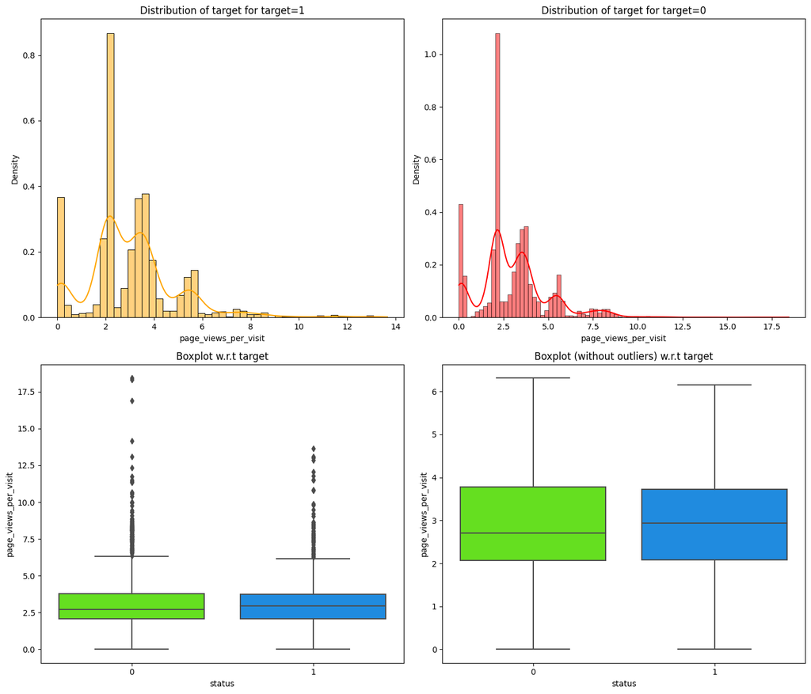

```python
distribution_plot_wrt_target(data,"page_views_per_visit","status")
```

Observation:

- Pages viewed per visit are around 2.5 pages based on the boxplots.
- According to the histograms, the data distribution is right skewed. We observe outliers in the yes category but even more in the No category.

```
status                 0     1   All
current_occupation
All                 3235  1377  4612
Professional        1687   929  2616
Unemployed          1058   383  1441
Student              490    65   555
------------------------------------------------------------------------------------------------------------------------
```

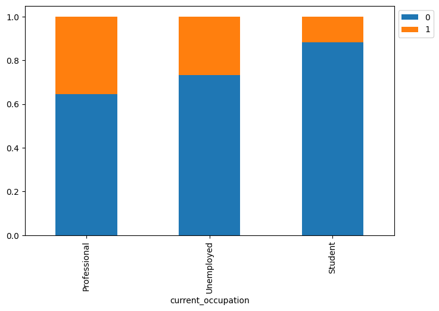

```python
stacked_barplot(data, "current_occupation", "status")
```

Observations: Question 1

- We observe here that a professional will have a higher likelihood of being converted 36%
- while an unemployed lead will have a slighly lower chance 27% of being converted
- student category is least likely to be converted 12%. We conclude that depending on which occupation background a lead comes from will impact their conversion rate. Employed professionals are most likely to be converted to paid customers.

```
status                0     1   All
first_interaction
All                3235  1377  4612
Website            1383  1159  2542
Mobile App         1852   218  2070
------------------------------------------------------------------------------------------------------------------------
```

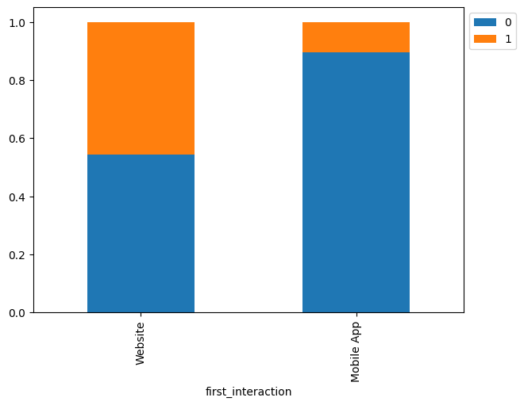

```python
stacked_barplot(data, "first_interaction", "status")
```

Observations: Quetion 2

- There are more total website visits than mobile app visits & a much better conversion rate as well 46% vs 10% respectivly.
- This is evidence that more people visit the website to get information on the company's services and more of them tend to be converted to paid customers.

```
status               0     1   All
last_activity
All               3235  1377  4612
Email Activity    1587   691  2278
Website Activity   677   423  1100
Phone Activity     971   263  1234
------------------------------------------------------------------------------------------------------------------------
```

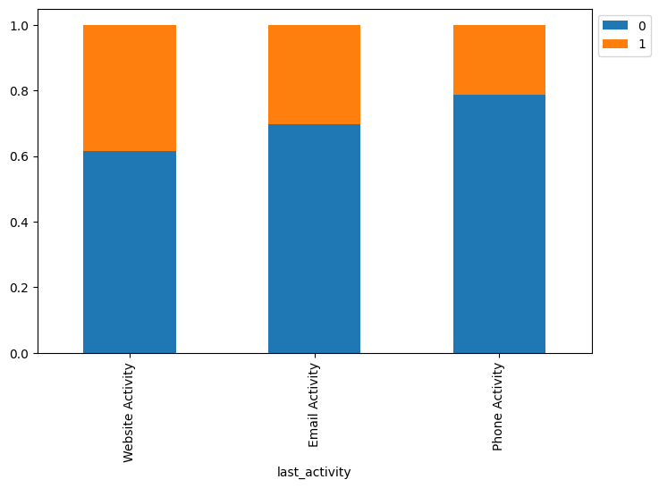

```python
stacked_barplot(data, "last_activity", "status")
```

Observation: Question 3

- Email conversion rate is 30%
- Website conversion rate is 38%
- Phone conversion rate is 21%
- We conclude that while email seems to be the most popular mode of communicaiton, the best conversion rate goes to the website.

```
status                0     1   All
print_media_type1
All                3235  1377  4612
No                 2897  1218  4115
Yes                 338   159   497
------------------------------------------------------------------------------------------------------------------------
```

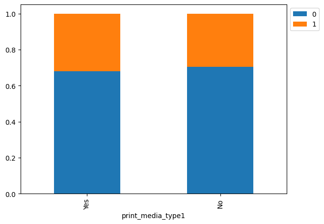

```python
stacked_barplot(data, "print_media_type1", "status")
```

Observation: Question 4

- The conversion rate for media type 1 (Newspaper) is 32%

```
status                0     1   All
print_media_type2
All                3235  1377  4612
No                 3077  1302  4379
Yes                 158    75   233
------------------------------------------------------------------------------------------------------------------------
```

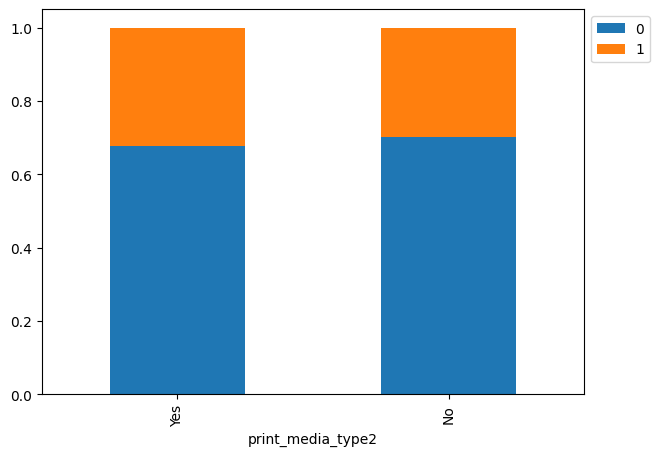

```python
stacked_barplot(data, "print_media_type2", "status")
```

Observation: Question 4

- The conversion rate for media type 2 (Magezine) is also 32%

```
status            0     1   All
digital_media
All            3235  1377  4612
No             2876  1209  4085
Yes             359   168   527
------------------------------------------------------------------------------------------------------------------------
```

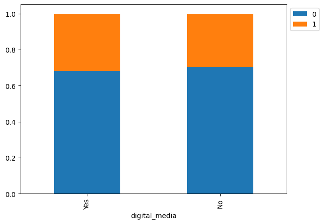

```python
stacked_barplot(data, "digital_media", "status")
```

Observation: Question 4

- The conversion rate for digital media is 32% as well

```
status       0     1   All
referral
All       3235  1377  4612
No        3205  1314  4519
Yes         30    63    93
------------------------------------------------------------------------------------------------------------------------
```

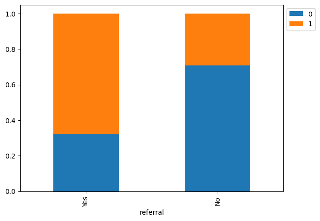

```python
stacked_barplot(data, "referral", "status")
```

Observation: Question 4

- The conversion rate for referrals is 67%
- We conclude that referrals have the highest conversion rate

```
status                0     1   All
profile_completed
All                3235  1377  4612
High               1318   946  2264
Medium             1818   423  2241
Low                  99     8   107
------------------------------------------------------------------------------------------------------------------------
```

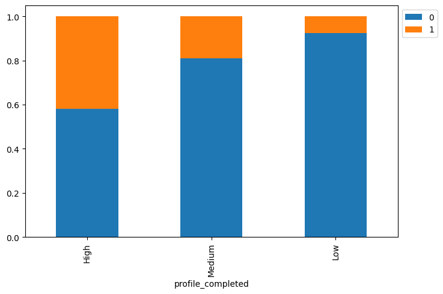

```python
stacked_barplot(data, "profile_completed", "status")
```

Observation: Question 5

- Leads with Low profile completion (0-50%) have a conversion rate of 7%
- Leads with medium profile completion (50-75%) have a conversion rate of 19%
- Leads with high profile completion (75-100%) have a conversion rate of 42%
- We conclude here that there's a strong correlation between profile compeltion and conversion rate. The more information extracted from the user, the more likely they are to be a paid customer.

### **Data Preprocessing**

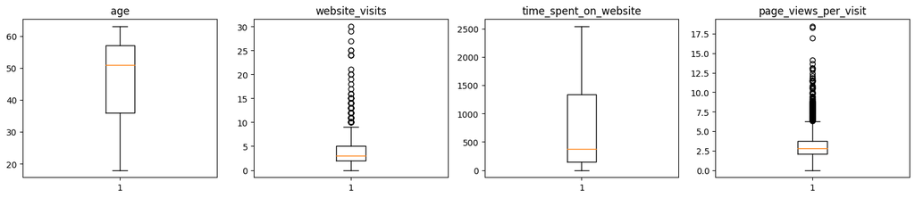

```python
# outlier detection using boxplot
numeric_columns = data.select_dtypes(include=np.number).columns.tolist()
# dropping release_year since it's a temporal variable
numeric_columns.remove("status")

plt.figure(figsize=(15, 12))

for i, variable in enumerate(numeric_columns):
    plt.subplot(4, 4, i + 1)
    plt.boxplot(data[variable], whis=1.5)
    plt.tight_layout()
    plt.title(variable)

plt.show()
```

Observation:

- There seems to be a lot of outliers for website visits
- There seems to be a lot of outliers for page views per visit as well

```python
# Dropping the target variable
X = data.drop(["status"], axis=1)
Y = data['status']

X = pd.get_dummies(X, drop_first=True)
```

```python
# Splitting the data
x_train, x_test, y_train, y_test = train_test_split(X, Y, test_size=0.3, random_state=1)
```

```python
print("Shape of Training set : ", x_train.shape)
print("Shape of test set : ", x_test.shape)
print("Percentage of classes in training set:")
print(y_train.value_counts(normalize=True))
print("Percentage of classes in test set:")
print(y_test.value_counts(normalize=True))
```

```
Shape of Training set :  (3228, 16)
Shape of test set :  (1384, 16)
Percentage of classes in training set:
0    0.704151
1    0.295849
Name: status, dtype: float64
Percentage of classes in test set:
0    0.695087
1    0.304913
Name: status, dtype: float64
```

Observation:

- We split our dataset into 30/70 for testing and training respectively
- Data type we are working with is float to make it easier for the model to train on.

```python
# Creating a function to print the classification report and get confusion matrix
def metrics_score(actual, predicted):
    print(classification_report(actual, predicted))

    cm = confusion_matrix(actual, predicted)

    plt.figure(figsize = (8, 5))

    sns.heatmap(cm, annot = True,  fmt = '.2f', xticklabels = ['Not Converted', 'Converted'], yticklabels = ['Not Converted', 'Converted'])

    plt.ylabel('Actual')

    plt.xlabel('Predicted')

    plt.show()
```

```python
# Building decision tree model
d_tree = DecisionTreeClassifier(class_weight = {0: 0.17, 1: 0.83}, random_state = 1)
d_tree.fit(x_train, y_train)
```

```
DecisionTreeClassifier(class_weight={0: 0.17, 1: 0.83}, random_state=1)
```

```
              precision    recall  f1-score   support

           0       1.00      1.00      1.00      2273
           1       1.00      1.00      1.00       955

    accuracy                           1.00      3228
   macro avg       1.00      1.00      1.00      3228
weighted avg       1.00      1.00      1.00      3228
```

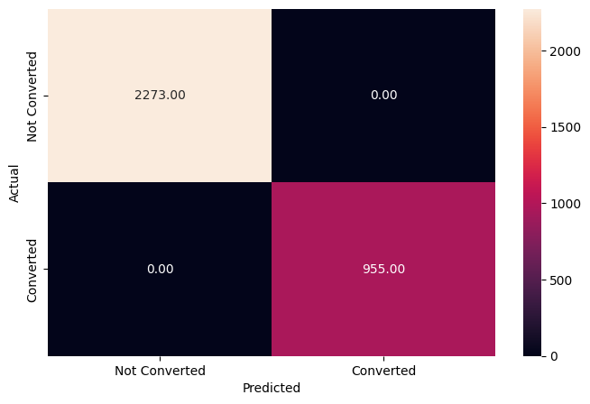

```python
# performance check on training data
y_train_pred_dt = d_tree.predict(x_train)

metrics_score(y_train, y_train_pred_dt)
```

Observation:

The Decision tree is giving a 100% score for all metrics on the training dataset, which shows us a perfect fit.

```python
def model_performance_classification(model, predictors, target):

    pred = model.predict(predictors)

    recall = recall_score(target, pred,average = 'macro')

    precision = precision_score(target, pred, average = 'macro')

    acc = accuracy_score(target, pred)

    df_perf = pd.DataFrame(
        {
            "Precision":  precision,
            "Recall":  recall,
            "Accuracy": acc,
        },

        index = [0],
    )

    return df_perf
```

```
              precision    recall  f1-score   support

           0       0.86      0.86      0.86       962
           1       0.68      0.69      0.68       422

    accuracy                           0.81      1384
   macro avg       0.77      0.77      0.77      1384
weighted avg       0.81      0.81      0.81      1384
```

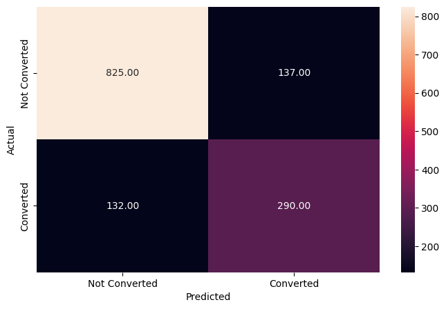

```python
# Checking performance on the testing data
y_test_pred_dt = d_tree.predict(x_test)

metrics_score(y_test, y_test_pred_dt)
```

```python
dtree_test = model_performance_classification(d_tree,x_test,y_test)
dtree_test
```

|  | Precision | Recall | Accuracy |
| --- | --- | --- | --- |
| 0 | 0.770613 | 0.772396 | 0.805636 |

Observations:

The Decision Tree works well on the training data but not as well on the test data as the recall is 0.77 in comparison to 1 for the training dataset, i.e., the Decision Tree is overfitting the training data.

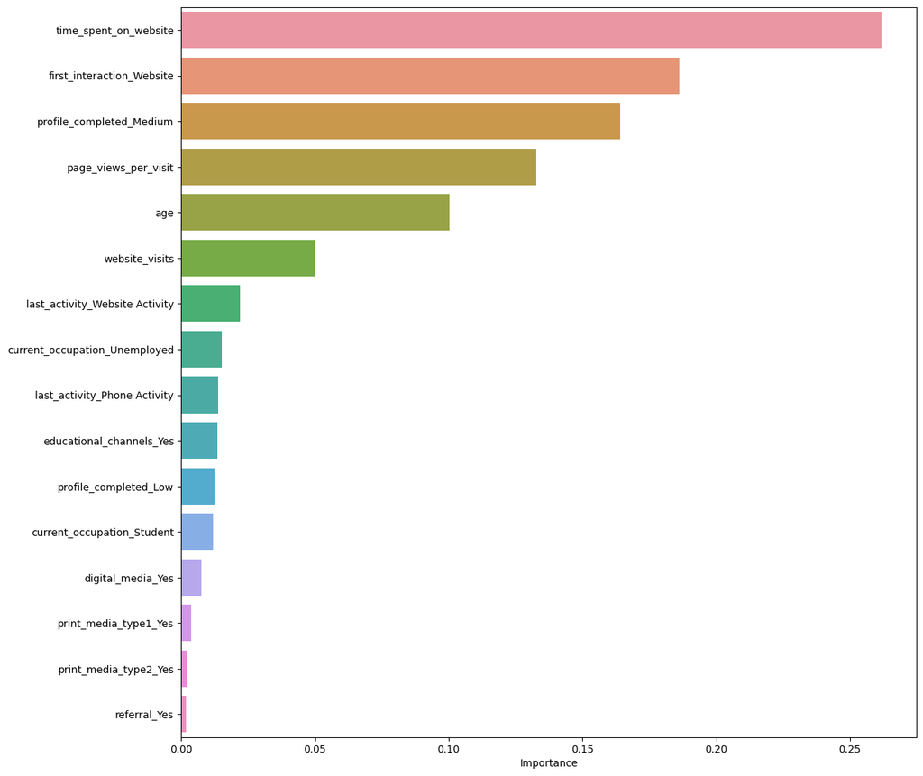

```python
# Plot the feature importance

importances = d_tree.feature_importances_

columns = X.columns

importance_df = pd.DataFrame(importances, index = columns, columns = ['Importance']).sort_values(by = 'Importance', ascending = False)

plt.figure(figsize = (13, 13))

sns.barplot(x=importance_df.Importance,y=importance_df.index);
```

Observation:

- As we can cleary see here, the most important variable according to the decision tree is time spent on website.
- Second most important variable is first interaction. This tells us that first interaction is imporatant.
- Profile completed halfway is the third most important variable.

```python
# Choose the type of classifier
dtree_estimator = DecisionTreeClassifier(class_weight = {0: 0.60, 1: 0.40}, random_state = 7)

# Grid of parameters to choose from
parameters = {'max_depth': np.arange(2, 20),
              'criterion': ['gini', 'entropy'],
              'min_samples_leaf': [5, 10, 20, 25]
             }

# Type of scoring used to compare parameter combinations
scorer = metrics.make_scorer(recall_score, pos_label = 1)

# Run the grid search
gridCV = GridSearchCV(dtree_estimator, parameters, scoring = scorer, cv = 5)

# Fitting the grid search on the train data
gridCV = gridCV.fit(x_train, y_train)

# Set the classifier to the best combination of parameters
dtree_estimator = gridCV.best_estimator_

# Fit the best estimator to the data
dtree_estimator.fit(x_train, y_train)
```

```
DecisionTreeClassifier(class_weight={0: 0.6, 1: 0.4}, max_depth=5,
                       min_samples_leaf=10, random_state=7)
```

```
              precision    recall  f1-score   support

           0       0.90      0.91      0.90      2273
           1       0.78      0.76      0.77       955

    accuracy                           0.86      3228
   macro avg       0.84      0.83      0.84      3228
weighted avg       0.86      0.86      0.86      3228
```

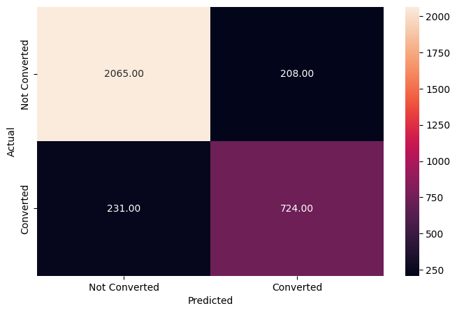

```python
# Checking performance on the train dataset
y_train_pred_dt = dtree_estimator.predict(x_train)

metrics_score(y_train, y_train_pred_dt)
```

```python
dtree_tuned_test = model_performance_classification(dtree_estimator,x_train,y_train)
dtree_tuned_test
```

|  | Precision | Recall | Accuracy |
| --- | --- | --- | --- |
| 0 | 0.838107 | 0.833303 | 0.864002 |

Observation:

- In comparison to the model with default values of hyperparameters, the performance on the training set has gone down considerabley.

```
              precision    recall  f1-score   support

           0       0.89      0.91      0.90       962
           1       0.77      0.73      0.75       422

    accuracy                           0.85      1384
   macro avg       0.83      0.82      0.82      1384
weighted avg       0.85      0.85      0.85      1384
```

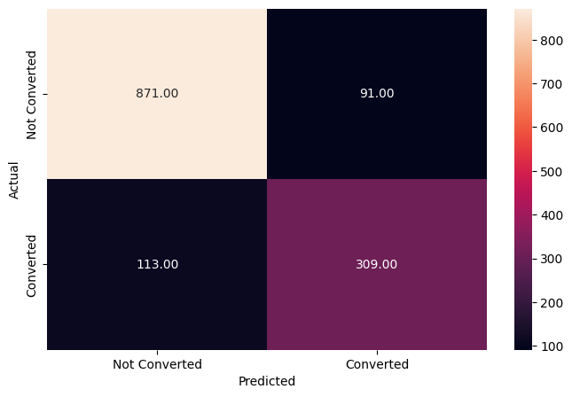

```python
# Checking performance on the test dataset
y_test_pred_dt = dtree_estimator.predict(x_test)

metrics_score(y_test, y_test_pred_dt)
```

```python
dtree_tuned_test = model_performance_classification(dtree_estimator,x_test,y_test)
dtree_tuned_test
```

|  | Precision | Recall | Accuracy |
| --- | --- | --- | --- |
| 0 | 0.828831 | 0.818816 | 0.852601 |

Observation:

- After adjusting class weights, the tuned model here is doing much better on recall at 0.81

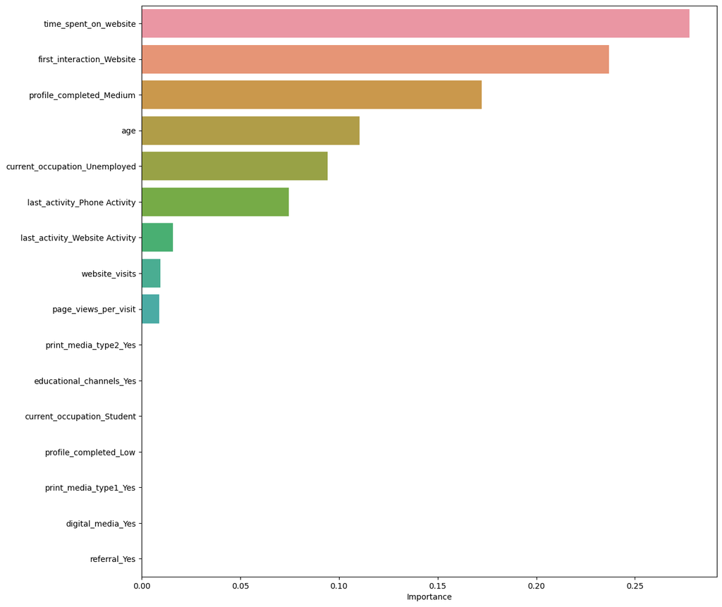

```python
importances = dtree_estimator.feature_importances_

columns = X.columns

importance_df = pd.DataFrame(importances, index = columns, columns = ['Importance']).sort_values(by = 'Importance', ascending = False)

plt.figure(figsize = (13, 13))

sns.barplot(x= importance_df.Importance, y= importance_df.index);
```

Observation:

- We notice in the tuned model that it is looking at less features in the data.
- The main ones are still prevelant: Time spent on website is still number one, second feature is first interaction (website) & profiel completed (medium or 50-75%) is the third one the model is looking at.

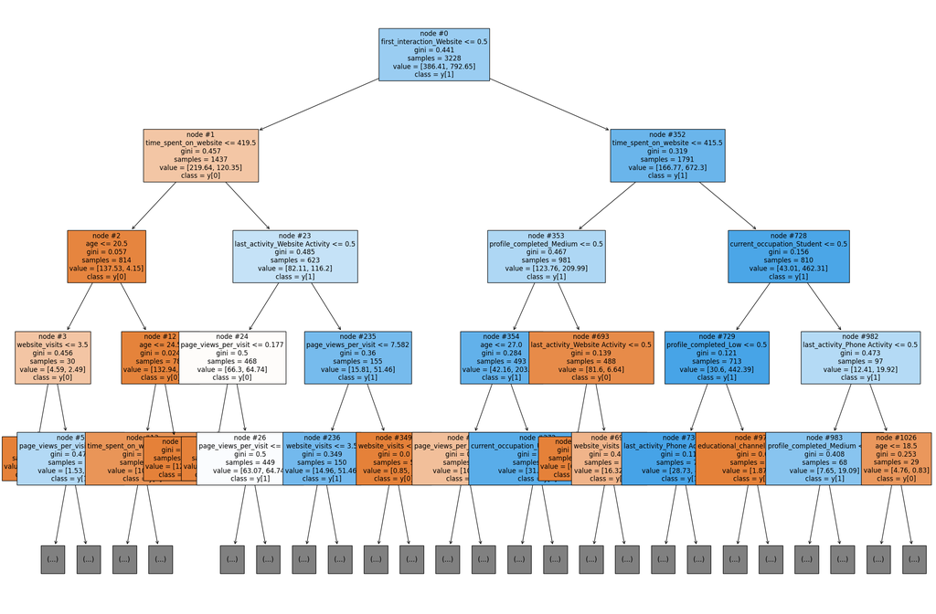

```python
#Visualizing the Decision Tree
features = list(X.columns)

plt.figure(figsize = (30, 20))

tree.plot_tree(d_tree, max_depth = 4, feature_names = features, filled = True, fontsize = 12, node_ids = True, class_names = True)

plt.show()
```

Note:

Observations:

## **Random Forest**

```python
# Fitting the Random Forest classifier on the training data
rf_estimator = RandomForestClassifier(class_weight = {0: 0.17, 1: 0.83}, random_state = 1)

rf_estimator.fit(x_train, y_train)
```

```
RandomForestClassifier(class_weight={0: 0.17, 1: 0.83}, random_state=1)
```

```
              precision    recall  f1-score   support

           0       1.00      1.00      1.00      2273
           1       1.00      1.00      1.00       955

    accuracy                           1.00      3228
   macro avg       1.00      1.00      1.00      3228
weighted avg       1.00      1.00      1.00      3228
```

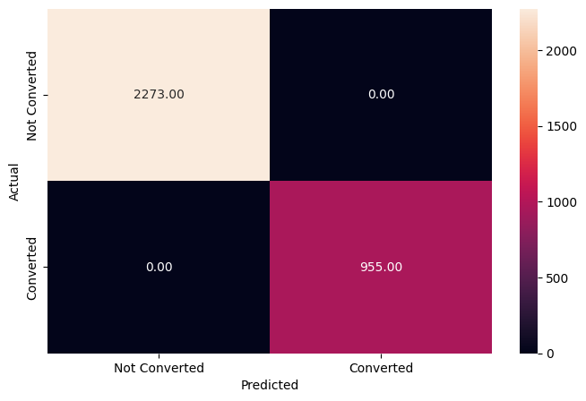

```python
# Checking performance on the training data
y_pred_train_rf = rf_estimator.predict(x_train)

metrics_score(y_train, y_pred_train_rf)
```

Observation:

- We observe here that the model was able to fit the data perfectly, but this is a sign of overfitting

```
              precision    recall  f1-score   support

           0       0.87      0.92      0.89       962
           1       0.80      0.68      0.73       422

    accuracy                           0.85      1384
   macro avg       0.83      0.80      0.81      1384
weighted avg       0.85      0.85      0.85      1384
```

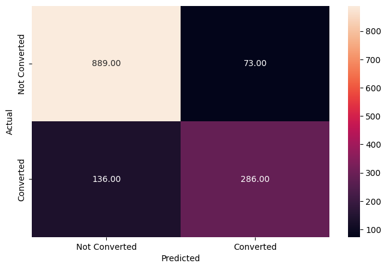

```python
# Checking performance on the testing data
y_pred_test_rf = rf_estimator.predict(x_test)

metrics_score(y_test, y_pred_test_rf)
```

```python
# Fitting the random forest tree classifier on the training data
rf_estimator_test = model_performance_classification(rf_estimator,x_test,y_test)
rf_estimator_test
```

|  | Precision | Recall | Accuracy |
| --- | --- | --- | --- |
| 0 | 0.831987 | 0.800921 | 0.848988 |

Observation:

- Recal went down on the testing data to 0.8 which means the model doesn't do as well on the testing data as it did on the training one.

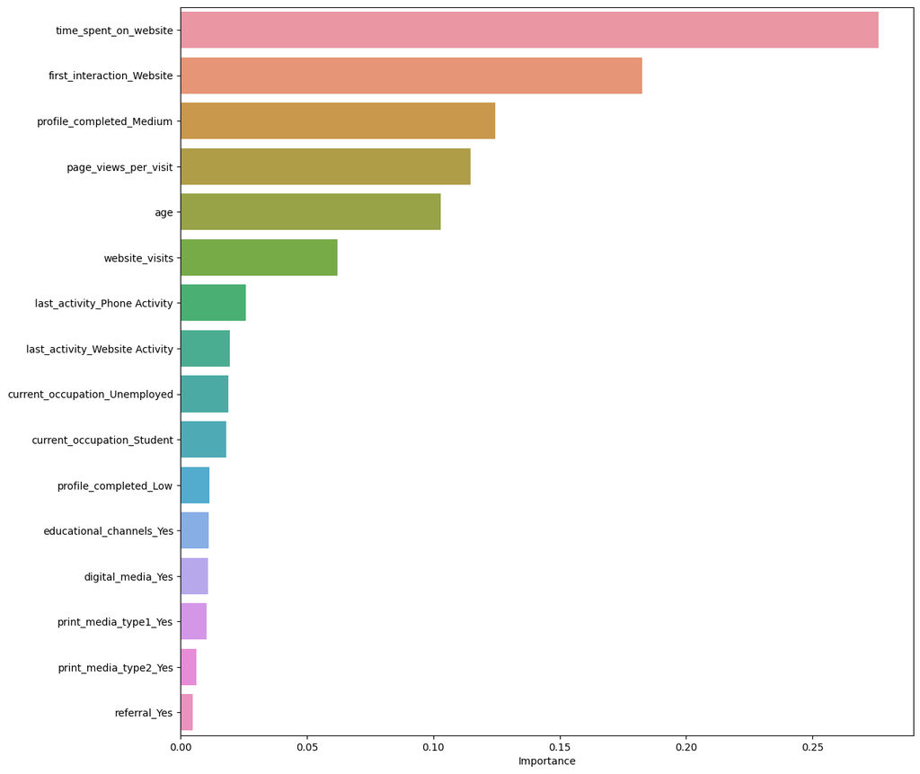

```python
importances = rf_estimator.feature_importances_

columns = X.columns

importance_df = pd.DataFrame(importances, index = columns, columns = ['Importance']).sort_values(by = 'Importance', ascending = False)

plt.figure(figsize = (13, 13))

sns.barplot(x= importance_df.Importance, y=importance_df.index);
```

Observation:

- We see here that according to the random forest model, the most important variables are: Time spent on website, first interaction, and profile completed (medium) in that order.

```python
# Choose the type of classifier
rf_estimator_tuned = RandomForestClassifier(criterion = "entropy", random_state = 7)

# Grid of parameters to choose from
params_rf = {
        "n_estimators": [100, 120],
        "min_samples_leaf": np.arange(1, 4, 1),
        "max_features": [0.7, 0.9, 'auto'],
}


# Type of scoring used to compare parameter combinations - recall score for class 1
scorer = metrics.make_scorer(recall_score, pos_label = 1)

# Run the grid search
grid_obj = GridSearchCV(rf_estimator_tuned, params_rf, scoring = scorer, cv = 10)

grid_obj = grid_obj.fit(x_train, y_train)

# Set the classifier to the best combination of parameters
rf_estimator_tuned = grid_obj.best_estimator_
```

```python
rf_estimator_tuned.fit(x_train, y_train)
```

```
RandomForestClassifier(criterion='entropy', max_features=0.9,
                       min_samples_leaf=3, random_state=7)
```

```
              precision    recall  f1-score   support

           0       0.96      0.98      0.97      2273
           1       0.95      0.90      0.93       955

    accuracy                           0.96      3228
   macro avg       0.96      0.94      0.95      3228
weighted avg       0.96      0.96      0.96      3228
```

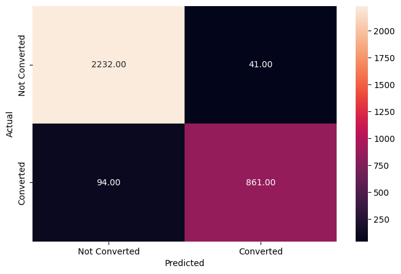

```python
# Checking performance on the training data
y_pred_train_rf_tuned = rf_estimator_tuned.predict(x_train)

metrics_score(y_train, y_pred_train_rf_tuned)
```

Observation:

- We observe that the model was able to obtain almost perfect score for recall on the training data.

```
              precision    recall  f1-score   support

           0       0.88      0.93      0.90       962
           1       0.81      0.71      0.76       422

    accuracy                           0.86      1384
   macro avg       0.84      0.82      0.83      1384
weighted avg       0.86      0.86      0.86      1384
```

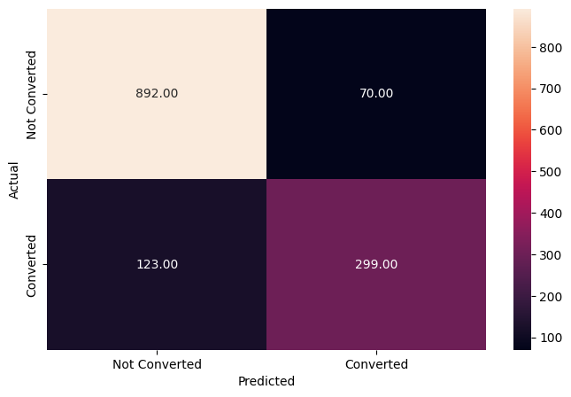

```python
# Checking performance on the test data
y_pred_test_rf_tuned = rf_estimator_tuned.predict(x_test)

metrics_score(y_test, y_pred_test_rf_tuned)
```

```python
rf_estimator_tuned_test = model_performance_classification(rf_estimator_tuned, x_test, y_test)
rf_estimator_tuned_test
```

|  | Precision | Recall | Accuracy |
| --- | --- | --- | --- |
| 0 | 0.844558 | 0.817883 | 0.860549 |

Observation:

- We observe here that there was a slight increase of about 3% after tuning the model.

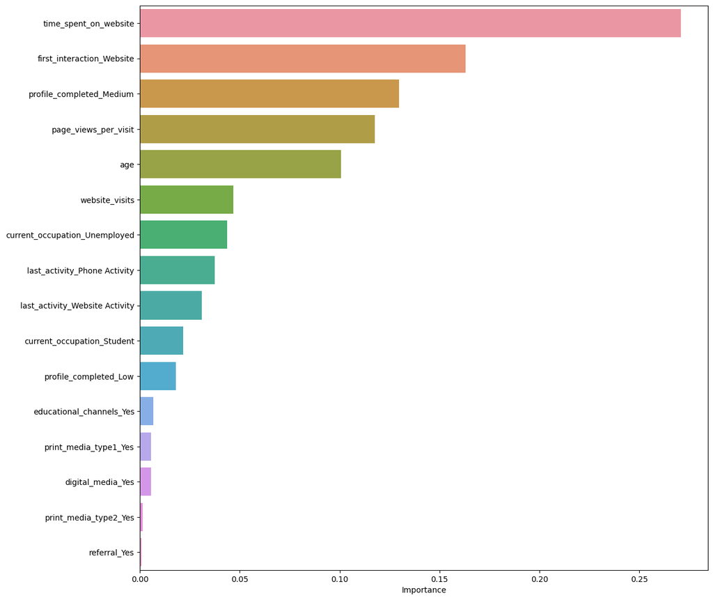

```python
# Plotting feature importance
importances = rf_estimator_tuned.feature_importances_

columns = X.columns

importance_df = pd.DataFrame(importances, index = columns, columns = ['Importance']).sort_values(by = 'Importance', ascending = False)

plt.figure(figsize = (13, 13))

sns.barplot(x= importance_df.Importance, y= importance_df.index)
```

Observation:

- According to the random forest model, the most important features are: time spent on website, first intereaction, and profile complete medium.

## **Reccomendation**:

There is a strong correlation between time spent on website and converted leads. We should give priority to those leads spending more than the average time of 12.5 minutes on the website as they are the most likely to be converted. Additionally, customers that first interact with the website are strong candidates to be converted. I suggest we provide them with just enough information for them to be interested so that they could provide us with their contact information for our agents to reach out to them and convert them to paid customers. Lastley, leads that took the time to fill out their infromation are a low hanging fruit, they are explicitly giving us conset to contact them to provide them with more information so they could make their decision, they should also be giving high priority before they lose interest later on. One way for letting our agents know the priority is giving them this information so they could also know the best way to approach the lead so they have a better chance at converting the leads.